# Springer Nature survey analysis

Rick Gilmore

2022-12-06

## Purpose

This document summarizes the results of a survey completed by Springer Nature in 2018.

The survey results are discussed in [(Stuart et al. 2018)](https://doi.org/10.6084/m9.figshare.5975011) and the raw data are found in [(Astell et al. 2018)](https://doi.org/10.6084/m9.figshare.5971387.v1).

## Setup

Ensure that we have the required package dependencies in the local environment.

```r
require(readxl)
library(tidyverse) # for pipe %>% operator
library(targets)
```

## Import

The data are in figshare. Here is the download link from the figshare API: https://figshare.com/ndownloader/files/10968194. The data file is an Excel spreadsheet in the .xlsx format.

By default, we do *not* download the datafile each time we run this report. Set `params$download_datafile` to `true` in the YAML header or run `rmarkdown::render("index.Rmd", params=list(download_datafile=TRUE))` to download the datafile.

```r
if (params$download_datafile) {
  message("Downloading datafile")
  download.file(url = "https://figshare.com/ndownloader/files/10968194", destfile = params$data_destfile)
} else {
  message("Using locally stored file: ", params$data_destfile)
  if (!file.exists(params$data_destfile)) {
    stop("Local data file not found: ", params$data_destfile)
  }
}
```

```
## Using locally stored file: data/survey.xlsx
```

```r
survey <- readxl::read_xlsx("data/survey.xlsx")
```

Examine the structure of the imported file.

```r
str(survey)
```

```
## tibble [7,718 × 24] (S3: tbl_df/tbl/data.frame)
##  $ Job title                                                                                                                                                                                                                                                       : chr [1:7718] "Director" "Postdoctora…
##  $ Country                                                                                                                                                                                                                                                         : chr [1:7718] "DE - Germany" "US - Un…
##  $ Generally, when submitting a manuscript to a journal what do you do with the data files generated by your research?                                                                                                                                             : chr [1:7718] "Submit files as supple…
##  $ Do your experiments generate data related to human research participants?                                                                                                                                                                                       : num [1:7718] 0 0 0 0 0 1 0 0 0 0 ...
##  $ Generally, what is the combined size of the data files you generate for each of your research articles?                                                                                                                                                         : chr [1:7718] "20Mb -100Mb" "100Mb - …
##  $ What subject area do your data relate to?                                                                                                                                                                                                                       : chr [1:7718] "Biological Sciences" "…
##  $ Are your data of any of the following types?Crystallographic data for small moleculesÂ DNA and RNA sequencesÂ DNA and RNA sequencing dataÂ Genetic polymorphismsÂ Linked genotype and phenotype dataÂ Macromolecular structureÂ Microarray dataProtein sequences: num [1:7718] 0 0 1 NA 0 1 1 1 NA 1 .…
##  $ Do you always deposit these data in dedicated community repositories?                                                                                                                                                                                           : num [1:7718] NA NA 0 NA NA 1 1 0 NA …
##  $ Are you aware that these types of data should be deposited in a dedicated community repository?                                                                                                                                                                 : num [1:7718] 1 0 NA NA 1 NA NA NA NA…
##  $ Do you often generate data of other types to those listed above?                                                                                                                                                                                                : num [1:7718] 1 1 0 NA 1 1 1 0 NA 1 .…
##  $ How important is it to you that your data are discoverable?                                                                                                                                                                                                     : num [1:7718] 1 10 10 8 8 7 7 9 6 8 .…
##  $ Lack of time to deposit data                                                                                                                                                                                                                                    : chr [1:7718] NA "Lack of time to dep…
##  $ Organising data in a presentable and useful way                                                                                                                                                                                                                 : chr [1:7718] "Organising data in a p…
##  $ Not knowing which repository to use                                                                                                                                                                                                                             : chr [1:7718] NA "Not knowing which r…
##  $ Unsure about copyright and licensing                                                                                                                                                                                                                            : chr [1:7718] NA "Unsure about copyri…
```

[output cut: 9 more lines]

There are 7718 responses and 24 questions.

Here are the questions:

```r
names(survey)
```

```
##  [1] "Job title"
##  [2] "Country"
##  [3] "Generally, when submitting a manuscript to a journal what do you do with the data files generated by your research?"
##  [4] "Do your experiments generate data related to human research participants?"
##  [5] "Generally, what is the combined size of the data files you generate for each of your research articles?"
##  [6] "What subject area do your data relate to?"
##  [7] "Are your data of any of the following types?Crystallographic data for small moleculesÂ DNA and RNA sequencesÂ DNA and RNA sequencing dataÂ Genetic polymorphismsÂ Linked genotype and phenotype dataÂ Macromolecular structureÂ Microarray dataProtein sequences"
##  [8] "Do you always deposit these data in dedicated community repositories?"
##  [9] "Are you aware that these types of data should be deposited in a dedicated community repository?"
## [10] "Do you often generate data of other types to those listed above?"
## [11] "How important is it to you that your data are discoverable?"
## [12] "Lack of time to deposit data"
## [13] "Organising data in a presentable and useful way"
## [14] "Not knowing which repository to use"
## [15] "Unsure about copyright and licensing"
## [16] "Costs of sharing data"
## [17] "Other"
## [18] "How interested would you be in a service that helps you deposit your data in a repository?"
## [19] "How interested would you be in a service that helps improves the discoverability of your data?"
## [20] "Do you have data that is not currently shared that you would be interested in depositing in a repository?"
## [21] "Are there other ways in which you would like help dealing with your research data?"
## [22] "Please tell us what these are"
## [23] "Is there any additional information about your data that you think we should be aware of?"
## [24] "Please let us know what this is"
```

## Clean

### “Job title”

Rename.

```r
names(survey)[1] <- "job_title"
```

Examine (unique) values.

```r
length(unique(survey$job_title))
```

```
## [1] 2683
```

That field will require a lot of consolidation and cleaning. We’ll skip it for now.

### “Country”

Rename (to lowercase).

```r
names(survey)[2] <- tolower(names(survey)[2])
```

Examine (unique) values.

```r
length(unique(survey$country))
```

```
## [1] 126
```

So, there was a broad international set of respondents. We’ll just show the top of the list.

```r
by_country <- survey %>%
  dplyr::group_by(., country) %>%
  dplyr::summarise(., n_resp = n()) %>%
  dplyr::arrange(., desc(n_resp))

head(by_country) %>%
  knitr::kable(., format = 'html') %>%
  kableExtra::kable_classic(.)
```

| country | n_resp |
| --- | --- |
| US - United States | 1753 |
| IT - Italy | 735 |
| GB - United Kingdom | 615 |
| ES - Spain | 558 |
| DE - Germany | 435 |
| CA - Canada | 412 |

### “Generally, when submitting a manuscript to a journal what do you do with the data files generated by your research?”

Rename.

```r
names(survey)[3] <- "what_do_with_data"
```

Examine unique responses.

```r
length(unique(survey$what_do_with_data))
```

```
## [1] 5
```

```r
unique(survey$what_do_with_data)
```

```
## [1] "Submit files as supplementary information"
## [2] "Deposit files in a repository"
## [3] "Both"
## [4] "Neither"
## [5] NA
```

These values could be simplified and made lowercase.

```r
survey <- survey %>%
  dplyr::mutate(
    .,
    what_do_with_data = dplyr::recode(what_do_with_data, "Submit files as supplementary information" = "submit_suppl")
  ) %>%
  dplyr::mutate(
    .,
    what_do_with_data = dplyr::recode(what_do_with_data, "Deposit files in a repository" = "deposit_repo")
  ) %>%
  dplyr::mutate(., what_do_with_data = tolower(what_do_with_data))
```

```r
xtabs(formula = ~ what_do_with_data, data = survey)
```

```
## what_do_with_data
##         both deposit_repo      neither submit_suppl
##         1546         1626         2849         1675
```

### “Do your experiments generate data related to human research participants?”

Rename.

```r
names(survey)[4] <- "generate_human_data"
```

Examine unique values.

```r
unique(survey$generate_human_data)
```

```
## [1]  0  1 NA
```

Recode the 0, 1 values as `FALSE`, `TRUE`.

```r
survey <- survey %>%
  dplyr::mutate(., generate_human_data = as.logical(generate_human_data))
```

```r
xtabs(formula = ~ generate_human_data, data = survey)
```

```
## generate_human_data
## FALSE  TRUE
##  3917  3766
```

### “Generally, what is the combined size of the data files you generate for each of your research articles?”

Rename.

```r
names(survey)[5] <- "file_size"
```

Examine unique values.

```r
unique(survey$file_size)
```

```
## [1] "20Mb -100Mb"  "100Mb - 1Gb"  "5Gb - 20Gb"   "<20Mb"        "1Gb - 5Gb"
## [6] "Don't know"   "20Gb - 50 Gb" NA             ">50Gb"
```

There are a small number of unique values and these have a logical ordering.

```r
ordered_file_sz <- forcats::fct_relevel(survey$file_size, c("<20Mb", "20Mb -100Mb", "100Mb - 1Gb", "1Gb - 5Gb", "5Gb - 20Gb", "20Gb - 50 Gb", ">50Gb"))

survey <- survey %>%
  dplyr::mutate(., file_size = ordered_file_sz)
```

Summarize.

```r
xtabs(formula = ~ file_size, data = survey)
```

```
## file_size
##        <20Mb  20Mb -100Mb  100Mb - 1Gb    1Gb - 5Gb   5Gb - 20Gb 20Gb - 50 Gb
##         2036         1860         1324          593          280          134
##        >50Gb   Don't know
##          286         1060
```

### “What subject area do your data relate to?”

Rename.

```r
names(survey)[6] <- "subject_area"
```

Recode.

```r
survey <- survey %>%
  dplyr::mutate(., subject_area = tolower(subject_area)) %>%
  dplyr::mutate(., subject_area = stringr::str_replace(subject_area, " ", "_"))
```

Summarize.

```r
xtabs(formula = ~ subject_area, data = survey)
```

```
## subject_area
## biological_sciences      earth_sciences    medical_sciences      other_sciences
##                2640                 365                2683                1511
##   physical_sciences
##                 486
```

### “Are your data of any of the following types?Crystallographic data for small moleculesÂ DNA and RNA sequencesÂ DNA and RNA sequencing dataÂ Genetic polymorphismsÂ Linked genotype and phenotype dataÂ Macromolecular structureÂ Microarray dataProtein sequences”

Rename.

```r
names(survey)[7] <- "molecular_or_gene_data"
```

Examine unique values

```r
unique(survey$molecular_or_gene_data)
```

```
## [1]  0  1 NA
```

Recode the 0, 1 values as `FALSE`, `TRUE`.

```r
survey <- survey %>%
  dplyr::mutate(., molecular_or_gene_data = as.logical(molecular_or_gene_data))
```

Summarize.

```r
xtabs(formula = ~ molecular_or_gene_data, data = survey)
```

```
## molecular_or_gene_data
## FALSE  TRUE
##  3017  2288
```

### “Do you always deposit these data in dedicated community repositories?”

Rename.

```r
names(survey)[8] <- "deposit_repo_always"
```

Examine unique values.

```r
unique(survey$deposit_repo_always)
```

```
## [1] NA  0  1
```

Recode the 0, 1 values as `FALSE`, `TRUE`.

```r
survey <- survey %>%
  dplyr::mutate(., deposit_repo_always = as.logical(deposit_repo_always))
```

Summarize.

```r
xtabs(formula = ~ deposit_repo_always, data = survey)
```

```
## deposit_repo_always
## FALSE  TRUE
##  1038  1235
```

### “Are you aware that these types of data should be deposited in a dedicated community repository?”

Rename.

```r
names(survey)[9] <- "aware_should_deposit"
```

Examine unique values.

```r
unique(survey$aware_should_deposit)
```

```
## [1]  1  0 NA
```

Recode the 0, 1 values as `FALSE`, `TRUE`.

```r
survey <- survey %>%
  dplyr::mutate(., aware_should_deposit = as.logical(aware_should_deposit))
```

Summarize.

```r
xtabs(formula = ~ aware_should_deposit, data = survey)
```

```
## aware_should_deposit
## FALSE  TRUE
##  1898  2026
```

### “Do you often generate data of other types to those listed above?”

Rename.

```r
names(survey)[10] <- "generate_other_types"
```

Examine unique values.

```r
unique(survey$generate_other_types)
```

```
## [1]  1  0 NA
```

Recode the 0, 1 values as `FALSE`, `TRUE`.

```r
survey <- survey %>%
  dplyr::mutate(., generate_other_types = as.logical(generate_other_types))
```

Summarize.

```r
xtabs(formula = ~ aware_should_deposit, data = survey)
```

```
## aware_should_deposit
## FALSE  TRUE
##  1898  2026
```

### “How important is it to you that your data are discoverable?”

Rename.

```r
names(survey)[11] <- "data_discoverable_importance"
```

Examine unique values.

```r
unique(survey$data_discoverable_importance)
```

```
##  [1]  1 10  8  7  9  6  3  5  4 NA  2
```

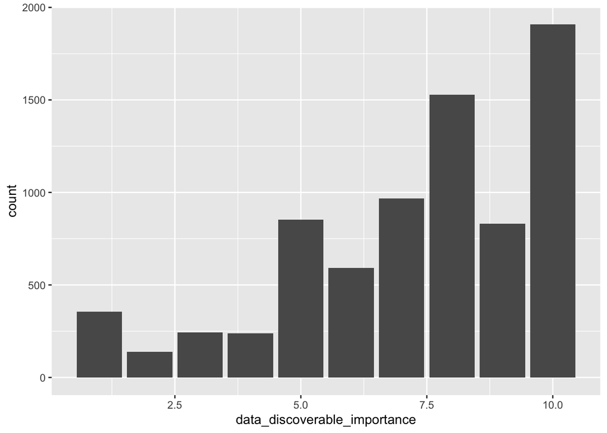

```r
survey %>%
  ggplot(.) +
  aes(x = data_discoverable_importance) +
  geom_bar()
```

### Questions about “barriers”

It looks like questions 12 to 17 relate to barriers. **Check the report to confirm this**. We can proceed with cleaning without confirming.

```r
names(survey)[12] <- "barrier_lack_of_time"
names(survey)[13] <- "barrier_organizing_data"
names(survey)[14] <- "barrier_which_repo"
names(survey)[15] <- "barrier_copyright_licensing"
names(survey)[16] <- "barrier_sharing_cost"
names(survey)[17] <- "barrier_other"
```

Recode values (except for `barrier_other`) as Booleans.

```r
# This is not elegant, but it is clear
lack_time <- stringr::str_detect(survey$barrier_lack_of_time, "Lack")
org_data <- stringr::str_detect(survey$barrier_organizing_data, "Organising")
dont_know_repo <- stringr::str_detect(survey$barrier_which_repo, "repository")
copyright <- stringr::str_detect(survey$barrier_copyright_licensing, "copyright")
costs <- stringr::str_detect(survey$barrier_sharing_cost, "Costs")

survey <- survey %>%
  dplyr::mutate(., barrier_lack_of_time = if_else(lack_time, TRUE, FALSE, missing = FALSE),
                barrier_organizing_data = if_else(org_data, TRUE, FALSE, missing = FALSE),
                barrier_which_repo = if_else(dont_know_repo, TRUE, FALSE, missing = FALSE),
                barrier_copyright_licensing = if_else(copyright, TRUE, FALSE, missing = FALSE),
                barrier_sharing_cost = if_else(costs, TRUE, FALSE, missing = FALSE))
```

```r
xtabs(formula = ~ barrier_lack_of_time, data = survey)
```

```
## barrier_lack_of_time
## FALSE  TRUE
##  5680  2038
```

```r
xtabs(formula = ~ barrier_organizing_data, data = survey)
```

```
## barrier_organizing_data
## FALSE  TRUE
##  4133  3585
```

```r
xtabs(formula = ~ barrier_which_repo, data = survey)
```

```
## barrier_which_repo
## FALSE  TRUE
##  5206  2512
```

```r
xtabs(formula = ~ barrier_copyright_licensing, data = survey)
```

```
## barrier_copyright_licensing
## FALSE  TRUE
##  4856  2862
```

```r
xtabs(formula = ~ barrier_sharing_cost, data = survey)
```

```
## barrier_sharing_cost
## FALSE  TRUE
##  6286  1432
```

The `barrier_other` category is a free-response field. Here is a sample of the responses:

```r
head(unique(survey$barrier_other))
```

```
## [1] NA
## [2] "Not permitted to share administrative data based on license"
## [3] "Question too vague - ability to mine data first is critical. Patent issues. most data not in these categories"
## [4] "the \"truly searchable\" databases are DNA/prots"
## [5] "Privacy and regulatory issues"
## [6] "Human subject restrictions"
```

### “How interested would you be in a service that helps you deposit your data in a repository?”

Rename.

```r
names(survey)[18] <- "interest_data_dep_service"
```

Examine unique values.

```r
unique(survey[,18])
```

```
## # A tibble: 12 × 1
##    interest_data_dep_service
##                        <dbl>
##  1                         7
##  2                         6
##  3                         0
##  4                         5
##  5                         3
##  6                         8
##  7                        10
##  8                         9
##  9                         2
## 10                         4
## 11                        NA
## 12                         1
```

This looks like a numeric scale in [0,10].

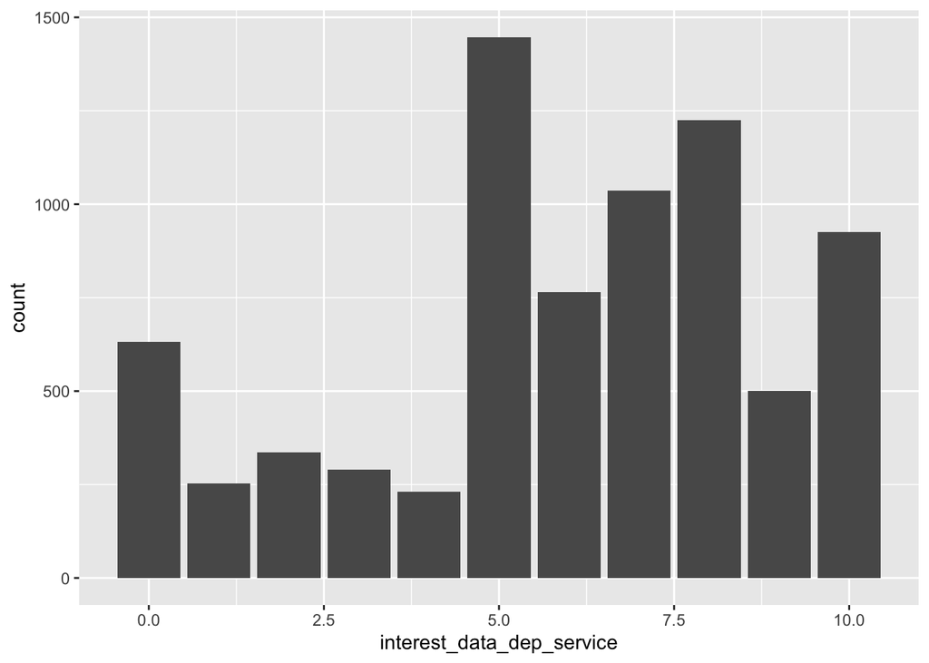

```r
survey %>%
  ggplot(.) +
  aes(x = interest_data_dep_service) +
  geom_bar()
```

### “How interested would you be in a service that helps improves the discoverability of your data?”

Rename.

```r
names(survey)[19] <- "interest_data_discov_service"
```

Examine unique values.

```r
unique(survey[,19])
```

```
## # A tibble: 12 × 1
##    interest_data_discov_service
##                           <dbl>
##  1                            7
##  2                            9
##  3                            6
##  4                            3
##  5                            5
##  6                           NA
##  7                            8
##  8                           10
##  9                            0
## 10                            2
## 11                            4
## 12                            1
```

This is also a numeric scale.

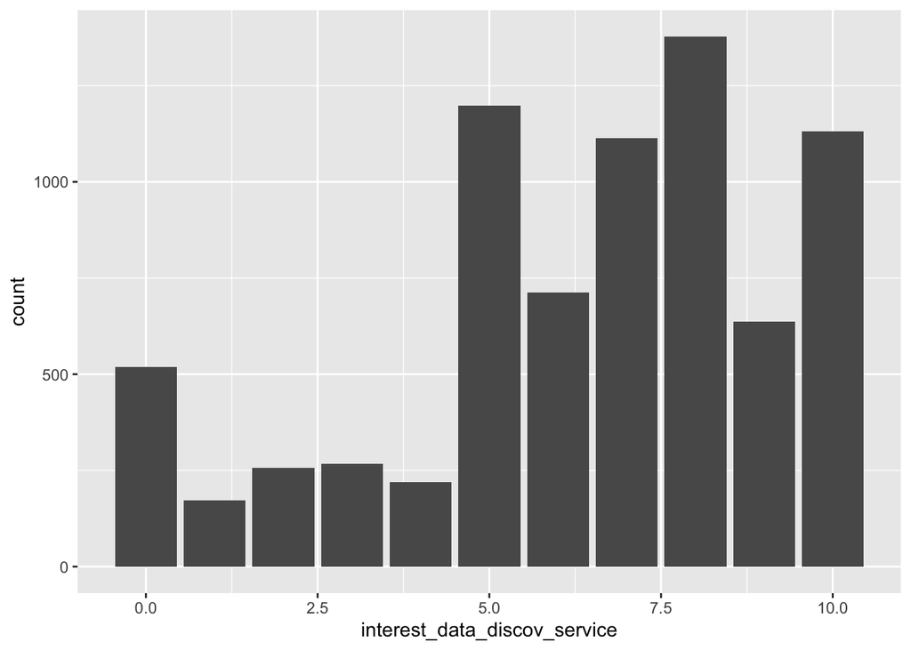

```r
survey %>%
  ggplot(.) +
  aes(x = interest_data_discov_service) +
  geom_bar()
```

### “Do you have data that is not currently shared that you would be interested in depositing in a repository?”

Rename.

```r
names(survey)[20] <- "have_data_to_deposit"
```

Examine unique values.

```r
unique(survey$have_data_to_deposit)
```

```
## [1]  1  0 NA
```

Recode this as a logical value.

```r
survey <- survey %>%
  dplyr::mutate(., have_data_to_deposit = as.logical(have_data_to_deposit))
```

Summarize.

```r
xtabs(formula = ~ have_data_to_deposit, data = survey)
```

```
## have_data_to_deposit
## FALSE  TRUE
##  5151  2495
```

### “Are there other ways in which you would like help dealing with your research data?”

Rename.

```r
names(survey)[21] <- "want_other_help"
```

Examine unique values.

```r
unique(survey$want_other_help)
```

```
## [1]  0  1 NA
```

Recode this as a logical value.

```r
survey <- survey %>%
  dplyr::mutate(., want_other_help = as.logical(want_other_help))
```

Summarize.

```r
xtabs(formula = ~ want_other_help, data = survey)
```

```
## want_other_help
## FALSE  TRUE
##  6290  1361
```

### “Please tell us what these are”

Rename.

```r
names(survey)[22] <- "want_help_with"
```

This is a free response field, so here are some examples:

```r
head(unique(survey$want_help_with))
```

```
## [1] NA                                    "some easier way of sharing the data"
## [3] "Free backup space."                  "Forums"
## [5] "A"                                   "management and analyses"
```

### “Is there any additional information about your data that you think we should be aware of?”

Rename.

```r
names(survey)[23] <- "have_addtl_info"
```

Recode this as a logical value.

```r
survey <- survey %>%
  dplyr::mutate(., have_addtl_info = as.logical(have_addtl_info))
```

Summarize.

```r
xtabs(formula = ~ have_addtl_info, data = survey)
```

```
## have_addtl_info
## FALSE  TRUE
##  6979   558
```

### “Please let us know what this is”

Rename.

```r
names(survey)[24] <- "addtl_info"
```

This is a free reponse field, so here are some examples.

```r
head(unique(survey$addtl_info))
```

```
## [1] NA
## [2] "Your survey Qu 5 restricted answering to a max of 20Gb. Boy, do you not understand the volumes of data generated by physical science! 10 times that - 200 Gb - would be a \"small\" project for me."
## [3] "Metadata only"
## [4] "my data is sound files and corresponding measurements taken from sound files. I'm never sure if it's more helpful to provide the raw audio or the measurements or both"
## [5] "Much of the data we use in health outcomes research is administrative data, often healthcare claims, and may not be shared based on the license agreement."
## [6] "my research issues"
```

## Save cleaned

```r
readr::write_csv(survey, "data/survey_clean.csv")
message("Saved cleaned data file: ", "data/survey_clean.csv")
```

```
## Saved cleaned data file: data/survey_clean.csv
```

## Cross-tabs

### Importance that data is discoverable by field

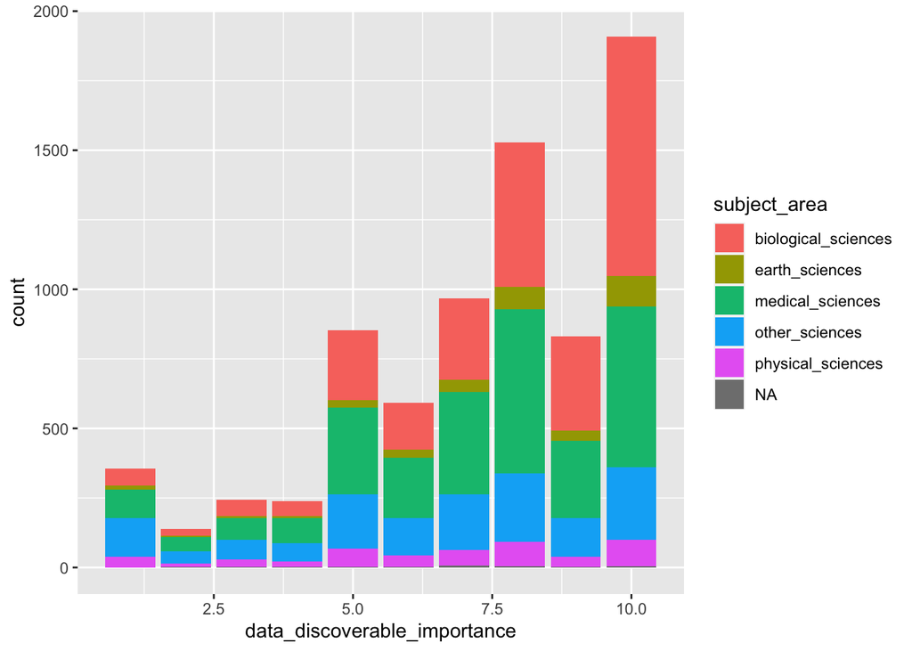

```r
survey %>%
  ggplot(.) +
  aes(x = data_discoverable_importance, fill = subject_area) +
  geom_bar()
```

### Interest in data deposit service by field

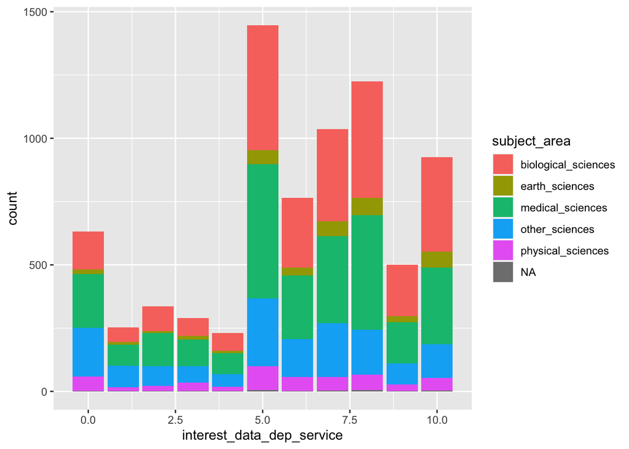

```r
survey %>%
  ggplot(.) +
  aes(x = interest_data_dep_service, fill = subject_area) +
  geom_bar()
```

### Interest in data deposit service for those who do or do not generate data from human participants

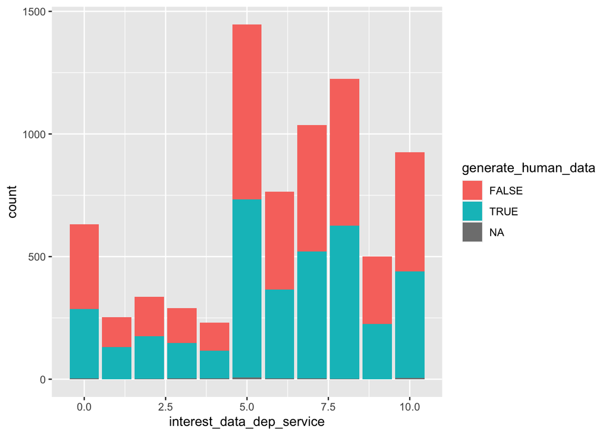

```r
survey %>%
  ggplot(.) +
  aes(x = interest_data_dep_service, fill = generate_human_data) +
  geom_bar()
```

### Interest in data discoverability service by field

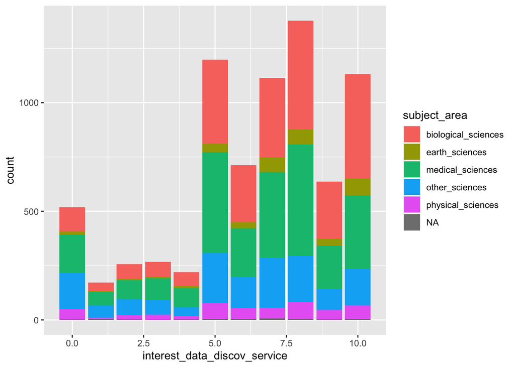

```r
survey %>%
  ggplot(.) +
  aes(x = interest_data_discov_service, fill = subject_area) +
  geom_bar()
```

### Prevalence of barriers to better data practices by subject area

```r
xtabs(formula = ~ subject_area + barrier_lack_of_time, data = survey)
```

```
##                      barrier_lack_of_time
## subject_area          FALSE TRUE
##   biological_sciences  1858  782
##   earth_sciences        251  114
##   medical_sciences     2012  671
##   other_sciences       1185  326
##   physical_sciences     353  133
```

```r
xtabs(formula = ~ subject_area + barrier_organizing_data, data = survey)
```

```
##                      barrier_organizing_data
## subject_area          FALSE TRUE
##   biological_sciences  1310 1330
##   earth_sciences        162  203
##   medical_sciences     1598 1085
##   other_sciences        834  677
##   physical_sciences     210  276
```

```r
xtabs(formula = ~ subject_area + barrier_which_repo, data = survey)
```

```
##                      barrier_which_repo
## subject_area          FALSE TRUE
##   biological_sciences  1789  851
##   earth_sciences        254  111
##   medical_sciences     1698  985
##   other_sciences       1081  430
##   physical_sciences     357  129
```

```r
xtabs(formula = ~ subject_area + barrier_copyright_licensing, data = survey)
```

```
##                      barrier_copyright_licensing
## subject_area          FALSE TRUE
##   biological_sciences  1762  878
##   earth_sciences        238  127
##   medical_sciences     1511 1172
##   other_sciences        989  522
##   physical_sciences     337  149
```

```r
xtabs(formula = ~ subject_area + barrier_sharing_cost, data = survey)
```

```
##                      barrier_sharing_cost
## subject_area          FALSE TRUE
##   biological_sciences  2125  515
##   earth_sciences        307   58
##   medical_sciences     2110  573
##   other_sciences       1308  203
##   physical_sciences     413   73
```

## References

Astell, Mathias, Iain Hrynaszkiewicz, Katie Allin, Dan Penny, Mithu Lucraft, Grace Baynes, and Scientific Data Admin. 2018. “Practical Challenges for Researchers in Data Sharing - Springer Nature Survey Data (Anonymised).” https://doi.org/10.6084/m9.figshare.5971387.v1.

Stuart, David, Grace Baynes, Hrynaszkiewicz Iain, Allin Katie, Dan Penny, Lucraft Mithu, and Mathias Astell. 2018. “Whitepaper: Practical Challenges for Researchers in Data Sharing.” https://doi.org/10.6084/m9.figshare.5975011.